# Risk Factor Analysis

## Outcome Variable

**Outcome Variable:** ever_stunted

## Predictor Variables

**Intervention Variable:** birthwt

**Adjustment Set:**

unadjusted

## Stratifying Variables

The analysis was stratified on these variable(s):

- agecat
- studyid
- country

## Data Summary

| agecat | studyid | country | birthwt | ever_stunted | n_cell | n |
| --- | --- | --- | --- | --- | --- | --- |
| 0-6 months | ki0047075b-MAL-ED | BANGLADESH | >=0 | 0 | 34 | 258 |
| 0-6 months | ki0047075b-MAL-ED | BANGLADESH | >=0 | 1 | 0 | 258 |
| 0-6 months | ki0047075b-MAL-ED | BANGLADESH | <-3 | 0 | 0 | 258 |
| 0-6 months | ki0047075b-MAL-ED | BANGLADESH | <-3 | 1 | 7 | 258 |
| 0-6 months | ki0047075b-MAL-ED | BANGLADESH | [-3–2) | 0 | 16 | 258 |
| 0-6 months | ki0047075b-MAL-ED | BANGLADESH | [-3–2) | 1 | 22 | 258 |
| 0-6 months | ki0047075b-MAL-ED | BANGLADESH | [-2–1) | 0 | 82 | 258 |
| 0-6 months | ki0047075b-MAL-ED | BANGLADESH | [-2–1) | 1 | 14 | 258 |
| 0-6 months | ki0047075b-MAL-ED | BANGLADESH | [-1-0) | 0 | 79 | 258 |
| 0-6 months | ki0047075b-MAL-ED | BANGLADESH | [-1-0) | 1 | 4 | 258 |
| 0-6 months | ki0047075b-MAL-ED | BRAZIL | >=0 | 0 | 123 | 233 |
| 0-6 months | ki0047075b-MAL-ED | BRAZIL | >=0 | 1 | 5 | 233 |
| 0-6 months | ki0047075b-MAL-ED | BRAZIL | [-3–2) | 0 | 2 | 233 |
| 0-6 months | ki0047075b-MAL-ED | BRAZIL | [-3–2) | 1 | 7 | 233 |
| 0-6 months | ki0047075b-MAL-ED | BRAZIL | [-2–1) | 0 | 16 | 233 |
| 0-6 months | ki0047075b-MAL-ED | BRAZIL | [-2–1) | 1 | 7 | 233 |
| 0-6 months | ki0047075b-MAL-ED | BRAZIL | [-1-0) | 0 | 67 | 233 |
| 0-6 months | ki0047075b-MAL-ED | BRAZIL | [-1-0) | 1 | 6 | 233 |
| 0-6 months | ki0047075b-MAL-ED | INDIA | >=0 | 0 | 44 | 245 |
| 0-6 months | ki0047075b-MAL-ED | INDIA | >=0 | 1 | 0 | 245 |
| 0-6 months | ki0047075b-MAL-ED | INDIA | <-3 | 0 | 0 | 245 |
| 0-6 months | ki0047075b-MAL-ED | INDIA | <-3 | 1 | 5 | 245 |
| 0-6 months | ki0047075b-MAL-ED | INDIA | [-3–2) | 0 | 12 | 245 |
| 0-6 months | ki0047075b-MAL-ED | INDIA | [-3–2) | 1 | 12 | 245 |
| 0-6 months | ki0047075b-MAL-ED | INDIA | [-2–1) | 0 | 62 | 245 |
| 0-6 months | ki0047075b-MAL-ED | INDIA | [-2–1) | 1 | 19 | 245 |
| 0-6 months | ki0047075b-MAL-ED | INDIA | [-1-0) | 0 | 86 | 245 |
| 0-6 months | ki0047075b-MAL-ED | INDIA | [-1-0) | 1 | 5 | 245 |
| 0-6 months | ki0047075b-MAL-ED | NEPAL | >=0 | 0 | 48 | 233 |
| 0-6 months | ki0047075b-MAL-ED | NEPAL | >=0 | 1 | 0 | 233 |

[output cut: 708 more lines]

The following strata were considered:

- agecat: 0-24 months, studyid: ki0047075b-MAL-ED, country: BANGLADESH
- agecat: 0-24 months, studyid: ki0047075b-MAL-ED, country: BRAZIL
- agecat: 0-24 months, studyid: ki0047075b-MAL-ED, country: INDIA
- agecat: 0-24 months, studyid: ki0047075b-MAL-ED, country: NEPAL
- agecat: 0-24 months, studyid: ki0047075b-MAL-ED, country: PERU
- agecat: 0-24 months, studyid: ki0047075b-MAL-ED, country: SOUTH AFRICA
- agecat: 0-24 months, studyid: ki0047075b-MAL-ED, country: TANZANIA, UNITED REPUBLIC OF
- agecat: 0-24 months, studyid: ki1000108-CMC-V-BCS-2002, country: INDIA
- agecat: 0-24 months, studyid: ki1000108-IRC, country: INDIA
- agecat: 0-24 months, studyid: ki1000109-EE, country: PAKISTAN
- agecat: 0-24 months, studyid: ki1000109-ResPak, country: PAKISTAN
- agecat: 0-24 months, studyid: ki1000304b-SAS-CompFeed, country: INDIA
- agecat: 0-24 months, studyid: ki1017093-NIH-Birth, country: BANGLADESH
- agecat: 0-24 months, studyid: ki1017093b-PROVIDE, country: BANGLADESH
- agecat: 0-24 months, studyid: ki1017093c-NIH-Crypto, country: BANGLADESH
- agecat: 0-24 months, studyid: ki1066203-TanzaniaChild2, country: TANZANIA, UNITED REPUBLIC OF
- agecat: 0-24 months, studyid: ki1101329-Keneba, country: GAMBIA
- agecat: 0-24 months, studyid: ki1114097-CMIN, country: BANGLADESH
- agecat: 0-24 months, studyid: ki1114097-CMIN, country: BRAZIL
- agecat: 0-24 months, studyid: ki1114097-CMIN, country: PERU
- agecat: 0-24 months, studyid: ki1114097-CONTENT, country: PERU
- agecat: 0-24 months, studyid: ki1119695-PROBIT, country: BELARUS
- agecat: 0-24 months, studyid: ki1126311-ZVITAMBO, country: ZIMBABWE
- agecat: 0-24 months, studyid: ki1135781-COHORTS, country: GUATEMALA
- agecat: 0-24 months, studyid: ki1135781-COHORTS, country: INDIA
- agecat: 0-24 months, studyid: ki1135781-COHORTS, country: PHILIPPINES
- agecat: 0-24 months, studyid: kiGH5241-JiVitA-3, country: BANGLADESH
- agecat: 0-24 months, studyid: kiGH5241-JiVitA-4, country: BANGLADESH
- agecat: 0-6 months, studyid: ki0047075b-MAL-ED, country: BANGLADESH
- agecat: 0-6 months, studyid: ki0047075b-MAL-ED, country: BRAZIL
- agecat: 0-6 months, studyid: ki0047075b-MAL-ED, country: INDIA
- agecat: 0-6 months, studyid: ki0047075b-MAL-ED, country: NEPAL
- agecat: 0-6 months, studyid: ki0047075b-MAL-ED, country: PERU
- agecat: 0-6 months, studyid: ki0047075b-MAL-ED, country: SOUTH AFRICA
- agecat: 0-6 months, studyid: ki0047075b-MAL-ED, country: TANZANIA, UNITED REPUBLIC OF
- agecat: 0-6 months, studyid: ki1000108-CMC-V-BCS-2002, country: INDIA
- agecat: 0-6 months, studyid: ki1000108-IRC, country: INDIA
- agecat: 0-6 months, studyid: ki1000109-EE, country: PAKISTAN
- agecat: 0-6 months, studyid: ki1000109-ResPak, country: PAKISTAN
- agecat: 0-6 months, studyid: ki1000304b-SAS-CompFeed, country: INDIA
- agecat: 0-6 months, studyid: ki1017093-NIH-Birth, country: BANGLADESH
- agecat: 0-6 months, studyid: ki1017093b-PROVIDE, country: BANGLADESH
- agecat: 0-6 months, studyid: ki1017093c-NIH-Crypto, country: BANGLADESH
- agecat: 0-6 months, studyid: ki1066203-TanzaniaChild2, country: TANZANIA, UNITED REPUBLIC OF
- agecat: 0-6 months, studyid: ki1101329-Keneba, country: GAMBIA
- agecat: 0-6 months, studyid: ki1114097-CMIN, country: BANGLADESH
- agecat: 0-6 months, studyid: ki1114097-CMIN, country: BRAZIL
- agecat: 0-6 months, studyid: ki1114097-CMIN, country: PERU
- agecat: 0-6 months, studyid: ki1114097-CONTENT, country: PERU
- agecat: 0-6 months, studyid: ki1119695-PROBIT, country: BELARUS
- agecat: 0-6 months, studyid: ki1126311-ZVITAMBO, country: ZIMBABWE
- agecat: 0-6 months, studyid: ki1135781-COHORTS, country: GUATEMALA
- agecat: 0-6 months, studyid: ki1135781-COHORTS, country: INDIA
- agecat: 0-6 months, studyid: ki1135781-COHORTS, country: PHILIPPINES
- agecat: 0-6 months, studyid: kiGH5241-JiVitA-3, country: BANGLADESH
- agecat: 0-6 months, studyid: kiGH5241-JiVitA-4, country: BANGLADESH
- agecat: 6-24 months, studyid: ki0047075b-MAL-ED, country: BANGLADESH
- agecat: 6-24 months, studyid: ki0047075b-MAL-ED, country: BRAZIL
- agecat: 6-24 months, studyid: ki0047075b-MAL-ED, country: INDIA
- agecat: 6-24 months, studyid: ki0047075b-MAL-ED, country: NEPAL
- agecat: 6-24 months, studyid: ki0047075b-MAL-ED, country: PERU
- agecat: 6-24 months, studyid: ki0047075b-MAL-ED, country: SOUTH AFRICA
- agecat: 6-24 months, studyid: ki0047075b-MAL-ED, country: TANZANIA, UNITED REPUBLIC OF
- agecat: 6-24 months, studyid: ki1000108-CMC-V-BCS-2002, country: INDIA
- agecat: 6-24 months, studyid: ki1000108-IRC, country: INDIA
- agecat: 6-24 months, studyid: ki1000109-EE, country: PAKISTAN
- agecat: 6-24 months, studyid: ki1000109-ResPak, country: PAKISTAN
- agecat: 6-24 months, studyid: ki1000304b-SAS-CompFeed, country: INDIA
- agecat: 6-24 months, studyid: ki1017093-NIH-Birth, country: BANGLADESH
- agecat: 6-24 months, studyid: ki1017093b-PROVIDE, country: BANGLADESH
- agecat: 6-24 months, studyid: ki1017093c-NIH-Crypto, country: BANGLADESH
- agecat: 6-24 months, studyid: ki1066203-TanzaniaChild2, country: TANZANIA, UNITED REPUBLIC OF
- agecat: 6-24 months, studyid: ki1101329-Keneba, country: GAMBIA
- agecat: 6-24 months, studyid: ki1114097-CMIN, country: BRAZIL
- agecat: 6-24 months, studyid: ki1114097-CMIN, country: PERU
- agecat: 6-24 months, studyid: ki1114097-CONTENT, country: PERU
- agecat: 6-24 months, studyid: ki1119695-PROBIT, country: BELARUS
- agecat: 6-24 months, studyid: ki1126311-ZVITAMBO, country: ZIMBABWE
- agecat: 6-24 months, studyid: ki1135781-COHORTS, country: GUATEMALA
- agecat: 6-24 months, studyid: ki1135781-COHORTS, country: INDIA
- agecat: 6-24 months, studyid: ki1135781-COHORTS, country: PHILIPPINES
- agecat: 6-24 months, studyid: kiGH5241-JiVitA-3, country: BANGLADESH
- agecat: 6-24 months, studyid: kiGH5241-JiVitA-4, country: BANGLADESH

### Dropped Strata

Some strata were dropped due to rare outcomes:

## Methods Detail

We’re interested in the causal parameters $E[Y_a]$ for all values of $a \in \mathcal{A}$. These parameters represent the mean outcome if, possibly contrary to fact, we intervened to set all units to have $A=a$. Under the randomization and positivity assumptions, these are identified by the statistical parameters $\psi_a=E_W[E_{Y|A,W}(Y|A=a,W)]$. In addition, we’re interested in the mean of $Y$, $E[Y]$ under no intervention (the observed mean). We will estimate these parameters by using SuperLearner to fit the relevant likelihood factors – $E_{Y|A,W}(Y|A=a,W)$ and $p(A=a|W)$, and then updating our likelihood fit using a joint TMLE.

For unadjusted analyses ($W=\{\}$), initial likelihoods were estimated using Lrnr_glm to estimate the simple $E(Y|A)$ and Lrnr_mean to estimate $p(A)$. For adjusted analyses, a small library containing Lrnr_glmnet, Lrnr_xgboost, and Lrnr_mean was used.

Having estimated these parameters, we will then use the delta method to estimate relative risks and attributable risks relative to a prespecified baseline level of $A$.

[output not shown]

# Results Detail

## Results Plots

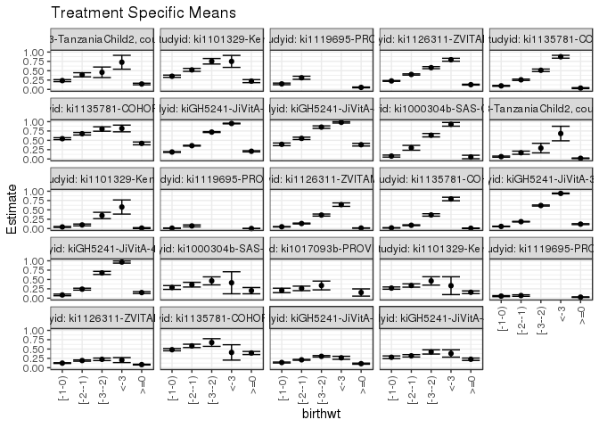

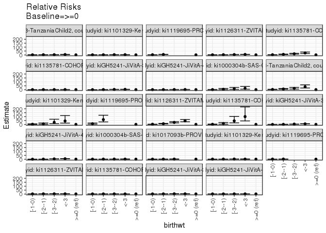

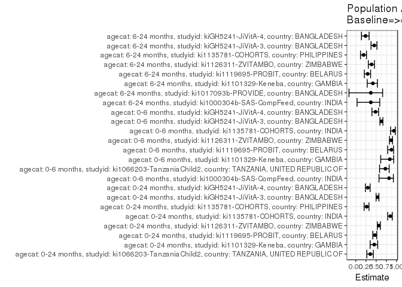

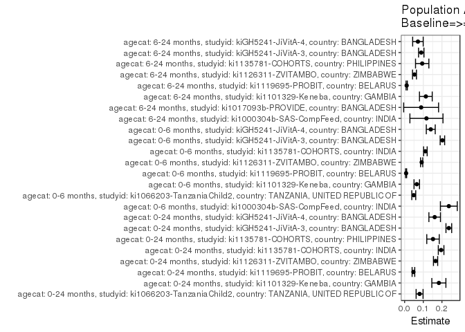

## Results Table

### Parameter: TSM

| agecat | studyid | country | intervention_level | baseline_level | estimate | ci_lower | ci_upper |
| --- | --- | --- | --- | --- | --- | --- | --- |
| 0-24 months | ki1066203-TanzaniaChild2 | TANZANIA, UNITED REPUBLIC OF | >=0 | NA | 0.1450828 | 0.1235389 | 0.1666267 |
| 0-24 months | ki1066203-TanzaniaChild2 | TANZANIA, UNITED REPUBLIC OF | <-3 | NA | 0.7272727 | 0.5411320 | 0.9134134 |
| 0-24 months | ki1066203-TanzaniaChild2 | TANZANIA, UNITED REPUBLIC OF | [-3–2) | NA | 0.4583333 | 0.3173474 | 0.5993193 |
| 0-24 months | ki1066203-TanzaniaChild2 | TANZANIA, UNITED REPUBLIC OF | [-2–1) | NA | 0.3914474 | 0.3365706 | 0.4463242 |
| 0-24 months | ki1066203-TanzaniaChild2 | TANZANIA, UNITED REPUBLIC OF | [-1-0) | NA | 0.2352941 | 0.2085806 | 0.2620076 |
| 0-24 months | ki1101329-Keneba | GAMBIA | >=0 | NA | 0.2214112 | 0.1812614 | 0.2615610 |
| 0-24 months | ki1101329-Keneba | GAMBIA | <-3 | NA | 0.7500000 | 0.5895749 | 0.9104251 |
| 0-24 months | ki1101329-Keneba | GAMBIA | [-3–2) | NA | 0.7538462 | 0.6797794 | 0.8279130 |
| 0-24 months | ki1101329-Keneba | GAMBIA | [-2–1) | NA | 0.5225376 | 0.4825278 | 0.5625473 |
| 0-24 months | ki1101329-Keneba | GAMBIA | [-1-0) | NA | 0.3522608 | 0.3218944 | 0.3826271 |
| 0-24 months | ki1119695-PROBIT | BELARUS | >=0 | NA | 0.0534170 | 0.0422128 | 0.0646211 |
| 0-24 months | ki1119695-PROBIT | BELARUS | [-2–1) | NA | 0.3116667 | 0.2704318 | 0.3529015 |
| 0-24 months | ki1119695-PROBIT | BELARUS | [-1-0) | NA | 0.1476043 | 0.1258281 | 0.1693805 |
| 0-24 months | ki1126311-ZVITAMBO | ZIMBABWE | >=0 | NA | 0.1268217 | 0.1153363 | 0.1383071 |
| 0-24 months | ki1126311-ZVITAMBO | ZIMBABWE | <-3 | NA | 0.7946860 | 0.7557752 | 0.8335968 |
| 0-24 months | ki1126311-ZVITAMBO | ZIMBABWE | [-3–2) | NA | 0.5824916 | 0.5544480 | 0.6105351 |
| 0-24 months | ki1126311-ZVITAMBO | ZIMBABWE | [-2–1) | NA | 0.4001769 | 0.3836863 | 0.4166676 |
| 0-24 months | ki1126311-ZVITAMBO | ZIMBABWE | [-1-0) | NA | 0.2270224 | 0.2162505 | 0.2377943 |
| 0-24 months | ki1135781-COHORTS | INDIA | >=0 | NA | 0.0345711 | 0.0217575 | 0.0473847 |
| 0-24 months | ki1135781-COHORTS | INDIA | <-3 | NA | 0.8745645 | 0.8362427 | 0.9128862 |
| 0-24 months | ki1135781-COHORTS | INDIA | [-3–2) | NA | 0.5120000 | 0.4788777 | 0.5451223 |
| 0-24 months | ki1135781-COHORTS | INDIA | [-2–1) | NA | 0.2571927 | 0.2393051 | 0.2750802 |
| 0-24 months | ki1135781-COHORTS | INDIA | [-1-0) | NA | 0.0955389 | 0.0840904 | 0.1069874 |
| 0-24 months | ki1135781-COHORTS | PHILIPPINES | >=0 | NA | 0.4174312 | 0.3796307 | 0.4552317 |
| 0-24 months | ki1135781-COHORTS | PHILIPPINES | <-3 | NA | 0.8169014 | 0.7269271 | 0.9068757 |
| 0-24 months | ki1135781-COHORTS | PHILIPPINES | [-3–2) | NA | 0.8022599 | 0.7435733 | 0.8609464 |
| 0-24 months | ki1135781-COHORTS | PHILIPPINES | [-2–1) | NA | 0.6763485 | 0.6422391 | 0.7104580 |
| 0-24 months | ki1135781-COHORTS | PHILIPPINES | [-1-0) | NA | 0.5433526 | 0.5171054 | 0.5695998 |
| 0-24 months | kiGH5241-JiVitA-3 | BANGLADESH | >=0 | NA | 0.2066752 | 0.1903777 | 0.2229728 |
| 0-24 months | kiGH5241-JiVitA-3 | BANGLADESH | <-3 | NA | 0.9506542 | 0.9412733 | 0.9600351 |

[output cut: 83 more lines]

### Parameter: E(Y)

| agecat | studyid | country | intervention_level | baseline_level | estimate | ci_lower | ci_upper |
| --- | --- | --- | --- | --- | --- | --- | --- |
| 0-24 months | ki1066203-TanzaniaChild2 | TANZANIA, UNITED REPUBLIC OF | NA | NA | 0.2253165 | 0.2084927 | 0.2421403 |
| 0-24 months | ki1101329-Keneba | GAMBIA | NA | NA | 0.4049080 | 0.3840027 | 0.4258132 |
| 0-24 months | ki1119695-PROBIT | BELARUS | NA | NA | 0.1006096 | 0.0848963 | 0.1163228 |
| 0-24 months | ki1126311-ZVITAMBO | ZIMBABWE | NA | NA | 0.2927003 | 0.2851706 | 0.3002300 |
| 0-24 months | ki1135781-COHORTS | INDIA | NA | NA | 0.2301329 | 0.2201057 | 0.2401602 |
| 0-24 months | ki1135781-COHORTS | PHILIPPINES | NA | NA | 0.5696245 | 0.5519304 | 0.5873185 |
| 0-24 months | kiGH5241-JiVitA-3 | BANGLADESH | NA | NA | 0.4435874 | 0.4360589 | 0.4511158 |
| 0-24 months | kiGH5241-JiVitA-4 | BANGLADESH | NA | NA | 0.5436182 | 0.5259510 | 0.5612854 |
| 0-6 months | ki1000304b-SAS-CompFeed | INDIA | NA | NA | 0.2899408 | 0.2636182 | 0.3162634 |
| 0-6 months | ki1066203-TanzaniaChild2 | TANZANIA, UNITED REPUBLIC OF | NA | NA | 0.0675105 | 0.0574070 | 0.0776141 |
| 0-6 months | ki1101329-Keneba | GAMBIA | NA | NA | 0.0779747 | 0.0661464 | 0.0898030 |
| 0-6 months | ki1119695-PROBIT | BELARUS | NA | NA | 0.0090570 | 0.0059070 | 0.0122070 |
| 0-6 months | ki1126311-ZVITAMBO | ZIMBABWE | NA | NA | 0.1050114 | 0.0999345 | 0.1100884 |
| 0-6 months | ki1135781-COHORTS | INDIA | NA | NA | 0.1191624 | 0.1113681 | 0.1269567 |
| 0-6 months | kiGH5241-JiVitA-3 | BANGLADESH | NA | NA | 0.3212848 | 0.3145332 | 0.3280365 |
| 0-6 months | kiGH5241-JiVitA-4 | BANGLADESH | NA | NA | 0.2894327 | 0.2741277 | 0.3047377 |
| 6-24 months | ki1000304b-SAS-CompFeed | INDIA | NA | NA | 0.3169456 | 0.2869579 | 0.3469333 |
| 6-24 months | ki1017093b-PROVIDE | BANGLADESH | NA | NA | 0.2394366 | 0.2018814 | 0.2769918 |
| 6-24 months | ki1101329-Keneba | GAMBIA | NA | NA | 0.2709966 | 0.2503773 | 0.2916160 |
| 6-24 months | ki1119695-PROBIT | BELARUS | NA | NA | 0.0380298 | 0.0285924 | 0.0474672 |
| 6-24 months | ki1126311-ZVITAMBO | ZIMBABWE | NA | NA | 0.1364126 | 0.1294320 | 0.1433931 |
| 6-24 months | ki1135781-COHORTS | PHILIPPINES | NA | NA | 0.4883615 | 0.4674262 | 0.5092967 |
| 6-24 months | kiGH5241-JiVitA-3 | BANGLADESH | NA | NA | 0.1974469 | 0.1893928 | 0.2055011 |
| 6-24 months | kiGH5241-JiVitA-4 | BANGLADESH | NA | NA | 0.2982358 | 0.2800848 | 0.3163868 |

### Parameter: RR

| agecat | studyid | country | intervention_level | baseline_level | estimate | ci_lower | ci_upper |
| --- | --- | --- | --- | --- | --- | --- | --- |
| 0-24 months | ki1066203-TanzaniaChild2 | TANZANIA, UNITED REPUBLIC OF | >=0 | >=0 | 1.0000000 | 1.0000000 | 1.0000000 |
| 0-24 months | ki1066203-TanzaniaChild2 | TANZANIA, UNITED REPUBLIC OF | <-3 | >=0 | 5.0128127 | 3.7288356 | 6.7389109 |
| 0-24 months | ki1066203-TanzaniaChild2 | TANZANIA, UNITED REPUBLIC OF | [-3–2) | >=0 | 3.1591163 | 2.2450323 | 4.4453775 |
| 0-24 months | ki1066203-TanzaniaChild2 | TANZANIA, UNITED REPUBLIC OF | [-2–1) | >=0 | 2.6980970 | 2.1997249 | 3.3093808 |
| 0-24 months | ki1066203-TanzaniaChild2 | TANZANIA, UNITED REPUBLIC OF | [-1-0) | >=0 | 1.6217923 | 1.3452897 | 1.9551256 |
| 0-24 months | ki1101329-Keneba | GAMBIA | >=0 | >=0 | 1.0000000 | 1.0000000 | 1.0000000 |
| 0-24 months | ki1101329-Keneba | GAMBIA | <-3 | >=0 | 3.3873626 | 2.5590358 | 4.4838081 |
| 0-24 months | ki1101329-Keneba | GAMBIA | [-3–2) | >=0 | 3.4047337 | 2.7702117 | 4.1845941 |
| 0-24 months | ki1101329-Keneba | GAMBIA | [-2–1) | >=0 | 2.3600323 | 1.9383493 | 2.8734513 |
| 0-24 months | ki1101329-Keneba | GAMBIA | [-1-0) | >=0 | 1.5909800 | 1.3015645 | 1.9447499 |
| 0-24 months | ki1119695-PROBIT | BELARUS | >=0 | >=0 | 1.0000000 | 1.0000000 | 1.0000000 |
| 0-24 months | ki1119695-PROBIT | BELARUS | [-2–1) | >=0 | 5.8345996 | 4.9388165 | 6.8928565 |
| 0-24 months | ki1119695-PROBIT | BELARUS | [-1-0) | >=0 | 2.7632476 | 2.4367810 | 3.1334524 |
| 0-24 months | ki1126311-ZVITAMBO | ZIMBABWE | >=0 | >=0 | 1.0000000 | 1.0000000 | 1.0000000 |
| 0-24 months | ki1126311-ZVITAMBO | ZIMBABWE | <-3 | >=0 | 6.2661670 | 5.6531471 | 6.9456620 |
| 0-24 months | ki1126311-ZVITAMBO | ZIMBABWE | [-3–2) | >=0 | 4.5929960 | 4.1452677 | 5.0890831 |
| 0-24 months | ki1126311-ZVITAMBO | ZIMBABWE | [-2–1) | >=0 | 3.1554294 | 2.8565838 | 3.4855392 |
| 0-24 months | ki1126311-ZVITAMBO | ZIMBABWE | [-1-0) | >=0 | 1.7900909 | 1.6161161 | 1.9827940 |
| 0-24 months | ki1135781-COHORTS | INDIA | >=0 | >=0 | 1.0000000 | 1.0000000 | 1.0000000 |
| 0-24 months | ki1135781-COHORTS | INDIA | <-3 | >=0 | 25.2975649 | 17.4176156 | 36.7425030 |
| 0-24 months | ki1135781-COHORTS | INDIA | [-3–2) | >=0 | 14.8100613 | 10.1660988 | 21.5754263 |
| 0-24 months | ki1135781-COHORTS | INDIA | [-2–1) | >=0 | 7.4395299 | 5.1023128 | 10.8473562 |
| 0-24 months | ki1135781-COHORTS | INDIA | [-1-0) | >=0 | 2.7635484 | 1.8719509 | 4.0798077 |
| 0-24 months | ki1135781-COHORTS | PHILIPPINES | >=0 | >=0 | 1.0000000 | 1.0000000 | 1.0000000 |
| 0-24 months | ki1135781-COHORTS | PHILIPPINES | <-3 | >=0 | 1.9569726 | 1.6969135 | 2.2568868 |
| 0-24 months | ki1135781-COHORTS | PHILIPPINES | [-3–2) | >=0 | 1.9218973 | 1.7106999 | 2.1591685 |
| 0-24 months | ki1135781-COHORTS | PHILIPPINES | [-2–1) | >=0 | 1.6202636 | 1.4607318 | 1.7972183 |
| 0-24 months | ki1135781-COHORTS | PHILIPPINES | [-1-0) | >=0 | 1.3016579 | 1.1746908 | 1.4423482 |
| 0-24 months | kiGH5241-JiVitA-3 | BANGLADESH | >=0 | >=0 | 1.0000000 | 1.0000000 | 1.0000000 |
| 0-24 months | kiGH5241-JiVitA-3 | BANGLADESH | <-3 | >=0 | 4.5997492 | 4.2511389 | 4.9769470 |

[output cut: 83 more lines]

### Parameter: PAR

| agecat | studyid | country | intervention_level | baseline_level | estimate | ci_lower | ci_upper |
| --- | --- | --- | --- | --- | --- | --- | --- |
| 0-24 months | ki1066203-TanzaniaChild2 | TANZANIA, UNITED REPUBLIC OF | >=0 | NA | 0.0802337 | 0.0616615 | 0.0988059 |
| 0-24 months | ki1101329-Keneba | GAMBIA | >=0 | NA | 0.1834968 | 0.1457647 | 0.2212289 |
| 0-24 months | ki1119695-PROBIT | BELARUS | >=0 | NA | 0.0471926 | 0.0401281 | 0.0542571 |
| 0-24 months | ki1126311-ZVITAMBO | ZIMBABWE | >=0 | NA | 0.1658786 | 0.1545668 | 0.1771905 |
| 0-24 months | ki1135781-COHORTS | INDIA | >=0 | NA | 0.1955619 | 0.1805002 | 0.2106235 |
| 0-24 months | ki1135781-COHORTS | PHILIPPINES | >=0 | NA | 0.1521933 | 0.1187145 | 0.1856721 |
| 0-24 months | kiGH5241-JiVitA-3 | BANGLADESH | >=0 | NA | 0.2369122 | 0.2216151 | 0.2522092 |
| 0-24 months | kiGH5241-JiVitA-4 | BANGLADESH | >=0 | NA | 0.1611297 | 0.1301352 | 0.1921242 |
| 0-6 months | ki1000304b-SAS-CompFeed | INDIA | >=0 | NA | 0.2369607 | 0.1917716 | 0.2821498 |
| 0-6 months | ki1066203-TanzaniaChild2 | TANZANIA, UNITED REPUBLIC OF | >=0 | NA | 0.0490101 | 0.0384677 | 0.0595524 |
| 0-6 months | ki1101329-Keneba | GAMBIA | >=0 | NA | 0.0651212 | 0.0504281 | 0.0798144 |
| 0-6 months | ki1119695-PROBIT | BELARUS | >=0 | NA | 0.0079160 | 0.0050061 | 0.0108259 |
| 0-6 months | ki1126311-ZVITAMBO | ZIMBABWE | >=0 | NA | 0.0913383 | 0.0854665 | 0.0972102 |
| 0-6 months | ki1135781-COHORTS | INDIA | >=0 | NA | 0.1112677 | 0.1017136 | 0.1208217 |
| 0-6 months | kiGH5241-JiVitA-3 | BANGLADESH | >=0 | NA | 0.2025429 | 0.1905548 | 0.2145310 |
| 0-6 months | kiGH5241-JiVitA-4 | BANGLADESH | >=0 | NA | 0.1401239 | 0.1161965 | 0.1640514 |
| 6-24 months | ki1000304b-SAS-CompFeed | INDIA | >=0 | NA | 0.1169456 | 0.0283041 | 0.2055871 |
| 6-24 months | ki1017093b-PROVIDE | BANGLADESH | >=0 | NA | 0.0884932 | -0.0049573 | 0.1819438 |
| 6-24 months | ki1101329-Keneba | GAMBIA | >=0 | NA | 0.1137801 | 0.0796125 | 0.1479478 |
| 6-24 months | ki1119695-PROBIT | BELARUS | >=0 | NA | 0.0110790 | 0.0077154 | 0.0144427 |
| 6-24 months | ki1126311-ZVITAMBO | ZIMBABWE | >=0 | NA | 0.0528661 | 0.0423412 | 0.0633910 |
| 6-24 months | ki1135781-COHORTS | PHILIPPINES | >=0 | NA | 0.0942009 | 0.0584900 | 0.1299118 |
| 6-24 months | kiGH5241-JiVitA-3 | BANGLADESH | >=0 | NA | 0.0891911 | 0.0747456 | 0.1036365 |
| 6-24 months | kiGH5241-JiVitA-4 | BANGLADESH | >=0 | NA | 0.0713450 | 0.0431028 | 0.0995872 |

### Parameter: PAF

| agecat | studyid | country | intervention_level | baseline_level | estimate | ci_lower | ci_upper |
| --- | --- | --- | --- | --- | --- | --- | --- |
| 0-24 months | ki1066203-TanzaniaChild2 | TANZANIA, UNITED REPUBLIC OF | >=0 | NA | 0.3560933 | 0.2712511 | 0.4310581 |
| 0-24 months | ki1101329-Keneba | GAMBIA | >=0 | NA | 0.4531814 | 0.3524777 | 0.5382236 |
| 0-24 months | ki1119695-PROBIT | BELARUS | >=0 | NA | 0.4690667 | 0.4181924 | 0.5154924 |
| 0-24 months | ki1126311-ZVITAMBO | ZIMBABWE | >=0 | NA | 0.5667182 | 0.5282661 | 0.6020361 |
| 0-24 months | ki1135781-COHORTS | INDIA | >=0 | NA | 0.8497777 | 0.7832210 | 0.8958998 |
| 0-24 months | ki1135781-COHORTS | PHILIPPINES | >=0 | NA | 0.2671818 | 0.2053930 | 0.3241658 |
| 0-24 months | kiGH5241-JiVitA-3 | BANGLADESH | >=0 | NA | 0.5340823 | 0.4980693 | 0.5675113 |
| 0-24 months | kiGH5241-JiVitA-4 | BANGLADESH | >=0 | NA | 0.2964024 | 0.2364629 | 0.3516365 |
| 0-6 months | ki1000304b-SAS-CompFeed | INDIA | >=0 | NA | 0.8172726 | 0.5694951 | 0.9224415 |
| 0-6 months | ki1066203-TanzaniaChild2 | TANZANIA, UNITED REPUBLIC OF | >=0 | NA | 0.7259615 | 0.5842311 | 0.8193778 |
| 0-6 months | ki1101329-Keneba | GAMBIA | >=0 | NA | 0.8351584 | 0.6120525 | 0.9299577 |
| 0-6 months | ki1119695-PROBIT | BELARUS | >=0 | NA | 0.8740191 | 0.7823939 | 0.9270646 |
| 0-6 months | ki1126311-ZVITAMBO | ZIMBABWE | >=0 | NA | 0.8697943 | 0.8262288 | 0.9024376 |
| 0-6 months | ki1135781-COHORTS | INDIA | >=0 | NA | 0.9337481 | 0.8534829 | 0.9700423 |
| 0-6 months | kiGH5241-JiVitA-3 | BANGLADESH | >=0 | NA | 0.6304153 | 0.5925397 | 0.6647701 |
| 0-6 months | kiGH5241-JiVitA-4 | BANGLADESH | >=0 | NA | 0.4841331 | 0.3962461 | 0.5592266 |
| 6-24 months | ki1000304b-SAS-CompFeed | INDIA | >=0 | NA | 0.3689769 | 0.0316859 | 0.5887800 |
| 6-24 months | ki1017093b-PROVIDE | BANGLADESH | >=0 | NA | 0.3695893 | -0.1660174 | 0.6591667 |
| 6-24 months | ki1101329-Keneba | GAMBIA | >=0 | NA | 0.4198581 | 0.2819083 | 0.5313070 |
| 6-24 months | ki1119695-PROBIT | BELARUS | >=0 | NA | 0.2913252 | 0.2102360 | 0.3640885 |
| 6-24 months | ki1126311-ZVITAMBO | ZIMBABWE | >=0 | NA | 0.3875457 | 0.3076796 | 0.4581985 |
| 6-24 months | ki1135781-COHORTS | PHILIPPINES | >=0 | NA | 0.1928917 | 0.1160766 | 0.2630314 |
| 6-24 months | kiGH5241-JiVitA-3 | BANGLADESH | >=0 | NA | 0.4517217 | 0.3745209 | 0.5193938 |
| 6-24 months | kiGH5241-JiVitA-4 | BANGLADESH | >=0 | NA | 0.2392236 | 0.1395822 | 0.3273259 |